# Stock Market Analysis Project

## **Stock Market Analysis Project**

Hunter Ryan

Stock Market Analysis Dataset: https://www.kaggle.com/datasets/thesnak/stock-market-analysis

## **1. Introduction**

This project investigates the existence and behavior of market regimes using unsupervised clustering techniques applied to equity market features. Multiple methods are used to evaluate the number of regimes, followed by visualization and interpretation across different clustering resolutions. A detailed analysis of a three-regime model examines regime persistence, transitions, and asset-level performance to assess the economic relevance of the identified market states.

The analysis proceeds in the following steps:

1. Preprocess market data and construct features capturing returns, volatility, momentum, intraday range, and volume behavior
2. Apply multiple clustering evaluation methods (Elbow, Silhouette, Calinski–Harabasz, Davies–Bouldin, and Gaussian Mixture Models) to assess the number of regimes
3. Visualize and interpret market regimes across different clustering resolutions
4. Perform a detailed temporal analysis of the selected three-regime model using regime duration and transition analysis
5. Evaluate the economic implications of market regimes through asset-level cumulative return analysis for Apple (AAPL) and Netflix (NFLX)

## **2. Data Preprocessing**

```python
import pandas as pd

# We need to parse so that the dates are not strings but actual times
df = pd.read_csv("/Users/hunterryan/Downloads/Stock Market Analysis Project/stocks.csv", parse_dates=["Date"])

df.head()
```

|  | Ticker | Date | Open | High | Low | Close | Adj Close | Volume |
| --- | --- | --- | --- | --- | --- | --- | --- | --- |
| 0 | AAPL | 2023-02-07 | 150.639999 | 155.229996 | 150.639999 | 154.649994 | 154.414230 | 83322600 |
| 1 | AAPL | 2023-02-08 | 153.880005 | 154.580002 | 151.169998 | 151.919998 | 151.688400 | 64120100 |
| 2 | AAPL | 2023-02-09 | 153.779999 | 154.330002 | 150.419998 | 150.869995 | 150.639999 | 56007100 |
| 3 | AAPL | 2023-02-10 | 149.460007 | 151.339996 | 149.220001 | 151.009995 | 151.009995 | 57450700 |
| 4 | AAPL | 2023-02-13 | 150.949997 | 154.259995 | 150.919998 | 153.850006 | 153.850006 | 62199000 |

```python
df.info()
```

```
<class 'pandas.core.frame.DataFrame'>
RangeIndex: 248 entries, 0 to 247
Data columns (total 8 columns):
 #   Column     Non-Null Count  Dtype
---  ------     --------------  -----
 0   Ticker     248 non-null    object
 1   Date       248 non-null    datetime64[ns]
 2   Open       248 non-null    float64
 3   High       248 non-null    float64
 4   Low        248 non-null    float64
 5   Close      248 non-null    float64
 6   Adj Close  248 non-null    float64
 7   Volume     248 non-null    int64
dtypes: datetime64[ns](1), float64(5), int64(1), object(1)
memory usage: 15.6+ KB
```

```python
# checking to see if there are missing values
df.isna().sum()
```

```
Ticker       0
Date         0
Open         0
High         0
Low          0
Close        0
Adj Close    0
Volume       0
dtype: int64
```

We compute log returns from adjusted closing prices to capture day-to-day market changes in a form that is stable and appropriate for regime detection.

```python
import numpy as np

df["log_return"] = np.log(df["Adj Close"] / df["Adj Close"].shift(1))
df = df.dropna()
```

Rolling volatility is computed as the 20-day standard deviation of log returns to quantify recent market risk and turbulence.

Momentum measures the deviation of the current adjusted price from its 20-day moving average to capture trend direction and strength.

Intraday range is calculated as the normalized difference between daily high and low prices to capture within-day market stress and uncertainty.

Volume activity compares daily trading volume to its 20-day average to identify abnormal market participation associated with regime shifts.

```python
# Rolling volatility
df["vol_20"] = df["log_return"].rolling(20).std()

# Momentum
df["mom_20"] = df["Adj Close"] / df["Adj Close"].rolling(20).mean() - 1

# Intraday range
df["range"] = (df["High"] - df["Low"]) / df["Close"]

# Volume activity
df["vol_ratio"] = df["Volume"] / df["Volume"].rolling(20).mean()

df = df.dropna()
```

Features are standardized to zero mean and unit variance to ensure that distance-based clustering methods treat all regime signals equally.

```python
from sklearn.preprocessing import StandardScaler

features = ["log_return", "vol_20", "mom_20", "range", "vol_ratio"]
X = df[features]

scaler = StandardScaler()
X_scaled = scaler.fit_transform(X)
```

After preprocessing and feature engineering, the analysis shifts to identifying market regimes by clustering the standardized feature set and determining the appropriate number of regimes. Multiple model selection and validation methods are applied, including a heuristic variance-based approach, internal cluster validation metrics, and a probabilistic likelihood-based model, to evaluate how different assumptions influence the choice of regime count. Together, these methods provide complementary perspectives on regime structure, allowing both statistical separation and interpretability to be assessed.

## **3. Heuristic Model Selection Method**

The elbow method evaluates the tradeoff between model complexity and clustering performance by measuring how within-cluster variance decreases as the number of clusters increases. The optimal number of regimes is chosen at the point where additional clusters yield diminishing reductions in variance.

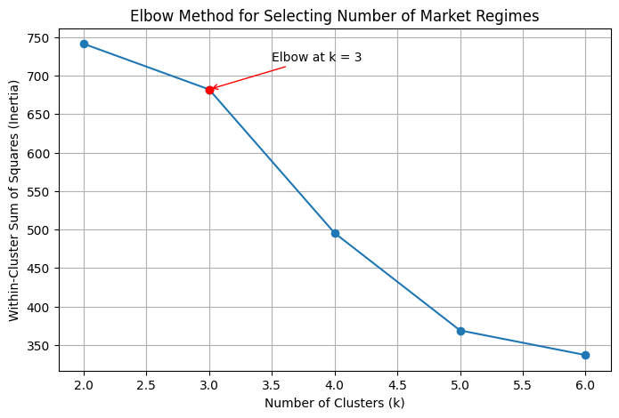

```python
import matplotlib.pyplot as plt
from sklearn.cluster import KMeans

inertias = []
k_values = list(range(2, 7))

for k in k_values:
    km = KMeans(n_clusters=k, random_state=42)
    km.fit(X_scaled)
    inertias.append(km.inertia_)

# Compute first and second differences
diff1 = np.diff(inertias)
diff2 = np.diff(diff1)

# Elbow index corresponds to max curvature
elbow_idx = np.argmax(np.abs(diff2)) + 1  # +1 aligns with k_values index
elbow_k = k_values[elbow_idx]
elbow_inertia = inertias[elbow_idx]

# Plot elbow curve
plt.figure(figsize=(8, 5))
plt.plot(k_values, inertias, marker='o')
plt.xlabel("Number of Clusters (k)")
plt.ylabel("Within-Cluster Sum of Squares (Inertia)")
plt.title("Elbow Method for Selecting Number of Market Regimes")
plt.grid(True)

# Highlight elbow point
plt.scatter(elbow_k, elbow_inertia, color="red", zorder=5)
plt.annotate(
    f"Elbow at k = {elbow_k}",
    xy=(elbow_k, elbow_inertia),
    xytext=(elbow_k + 0.5, elbow_inertia + 0.05 * inertias[0]),
    arrowprops=dict(arrowstyle="->", color="red")
)

plt.show()
```

## **4. Internal Cluster Validation Metrics**

The silhouette score measures how similar each observation is to its assigned cluster compared to other clusters, balancing within-cluster compactness and between-cluster separation. Higher silhouette values indicate more clearly defined regimes and are used to select the number of clusters that best separates market behavior.

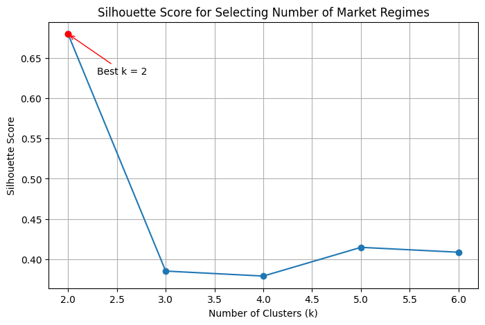

```python
from sklearn.metrics import silhouette_score

sil_scores = []
k_values = range(2, 7)

for k in k_values:
    km = KMeans(n_clusters=k, random_state=42)
    labels = km.fit_predict(X_scaled)
    sil_scores.append(silhouette_score(X_scaled, labels))

plt.figure(figsize=(8, 5))
plt.plot(k_values, sil_scores, marker='o')
plt.xlabel("Number of Clusters (k)")
plt.ylabel("Silhouette Score")
plt.title("Silhouette Score for Selecting Number of Market Regimes")
plt.grid(True)

# Highlight best k
best_k = k_values[sil_scores.index(max(sil_scores))]
plt.scatter(best_k, max(sil_scores), color="red", zorder=5)
plt.annotate(
    f"Best k = {best_k}",
    xy=(best_k, max(sil_scores)),
    xytext=(best_k + 0.3, max(sil_scores) - 0.05),
    arrowprops=dict(arrowstyle="->", color="red")
)

plt.show()
```

The Calinski–Harabasz index evaluates clustering quality by comparing between-cluster dispersion to within-cluster dispersion, with higher values indicating more compact and well-separated clusters. In the context of market regime detection, this metric tends to favor fewer regimes that capture broad structural differences in volatility and price behavior.

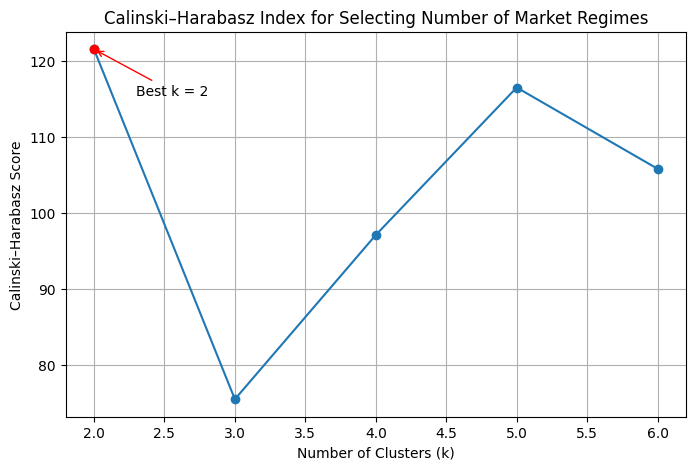

```python
from sklearn.metrics import calinski_harabasz_score

ch_scores = []
k_values = range(2, 7)

for k in k_values:
    km = KMeans(n_clusters=k, random_state=42)
    labels = km.fit_predict(X_scaled)
    ch_scores.append(calinski_harabasz_score(X_scaled, labels))

plt.figure(figsize=(8, 5))
plt.plot(k_values, ch_scores, marker='o')
plt.xlabel("Number of Clusters (k)")
plt.ylabel("Calinski–Harabasz Score")
plt.title("Calinski–Harabasz Index for Selecting Number of Market Regimes")
plt.grid(True)

# Highlight best k (maximize)
best_k = k_values[ch_scores.index(max(ch_scores))]
best_score = max(ch_scores)

plt.scatter(best_k, best_score, color="red", zorder=5)
plt.annotate(
    f"Best k = {best_k}",
    xy=(best_k, best_score),
    xytext=(best_k + 0.3, best_score * 0.95),
    arrowprops=dict(arrowstyle="->", color="red")
)

plt.show()
```

The Davies–Bouldin index measures the average similarity between each cluster and its most similar cluster, where lower values indicate less overlap and better separation. For financial time-series data, this metric penalizes overlapping regimes and often selects a smaller number of dominant market states.

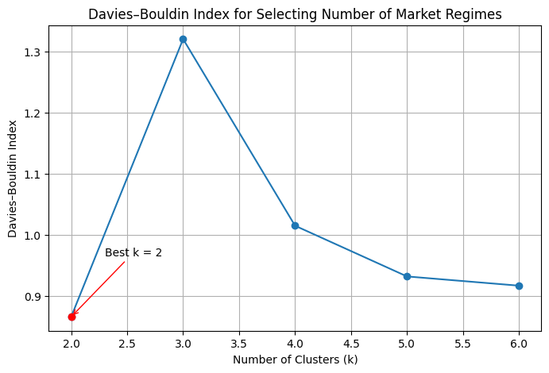

```python
from sklearn.metrics import davies_bouldin_score

db_scores = []
k_values = range(2, 7)

for k in k_values:
    km = KMeans(n_clusters=k, random_state=42)
    labels = km.fit_predict(X_scaled)
    db_scores.append(davies_bouldin_score(X_scaled, labels))

plt.figure(figsize=(8, 5))
plt.plot(k_values, db_scores, marker='o')
plt.xlabel("Number of Clusters (k)")
plt.ylabel("Davies–Bouldin Index")
plt.title("Davies–Bouldin Index for Selecting Number of Market Regimes")
plt.grid(True)

# Highlight best k (minimize)
best_k = k_values[db_scores.index(min(db_scores))]
best_score = min(db_scores)

plt.scatter(best_k, best_score, color="red", zorder=5)
plt.annotate(
    f"Best k = {best_k}",
    xy=(best_k, best_score),
    xytext=(best_k + 0.3, best_score + 0.1),
    arrowprops=dict(arrowstyle="->", color="red")
)

plt.show()
```

## **5. Probabilistic Model Selection Criterion**

A Gaussian Mixture Model represents the data as a weighted combination of multiple Gaussian distributions, allowing each observation to belong to multiple regimes with different probabilities rather than a single hard assignment. The optimal number of regimes is selected by minimizing the Bayesian Information Criterion (BIC), which balances model fit against complexity to avoid overfitting.

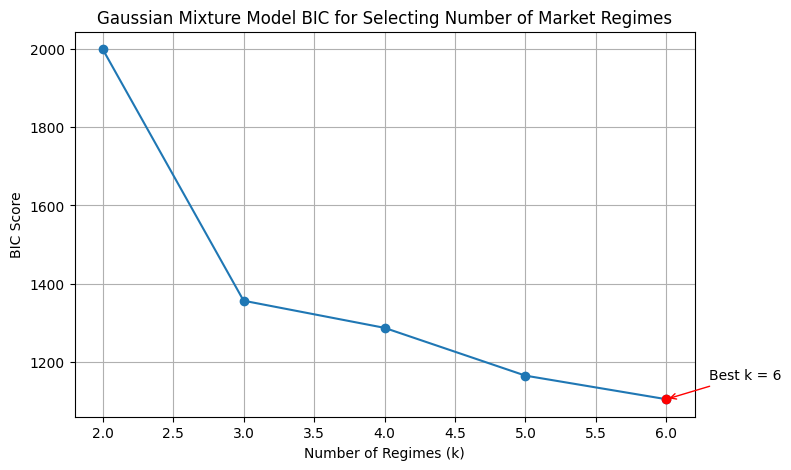

```python
from sklearn.mixture import GaussianMixture
import matplotlib.pyplot as plt

bic_scores = []
k_values = range(2, 7)

for k in k_values:
    gmm = GaussianMixture(
        n_components=k,
        covariance_type="full",
        random_state=42
    )
    gmm.fit(X_scaled)
    bic_scores.append(gmm.bic(X_scaled))

plt.figure(figsize=(8, 5))
plt.plot(k_values, bic_scores, marker='o')
plt.xlabel("Number of Regimes (k)")
plt.ylabel("BIC Score")
plt.title("Gaussian Mixture Model BIC for Selecting Number of Market Regimes")
plt.grid(True)

# Highlight best k (minimize BIC)
best_k = k_values[bic_scores.index(min(bic_scores))]
best_score = min(bic_scores)

plt.scatter(best_k, best_score, color="red", zorder=5)
plt.annotate(
    f"Best k = {best_k}",
    xy=(best_k, best_score),
    xytext=(best_k + 0.3, best_score + 50),
    arrowprops=dict(arrowstyle="->", color="red")
)

plt.show()
```

## **7. Market Regime Characterization Across Different k Values**

This section compares market regime behavior across multiple clustering resolutions by examining feature statistics and visual regime assignments for different values of k. By analyzing k = 2, k = 3, and k = 6, the results illustrate how market structure emerges at varying levels of granularity, from dominant regime splits to finer latent states.

```python
kmeans = KMeans(n_clusters=2, random_state=42)
df["regime"] = kmeans.fit_predict(X_scaled)
df.groupby("regime")[features].mean()
```

| regime | log_return | vol_20 | mom_20 | range | vol_ratio |
| --- | --- | --- | --- | --- | --- |
| 0 | 0.00412 | 0.028861 | 0.043277 | 0.023682 | 0.910843 |
| 1 | -0.06405 | 0.243951 | -0.504541 | 0.026405 | 1.921627 |

Regime 0 represents a low-volatility market environment characterized by modest positive log returns, relatively low rolling volatility, mild positive momentum, and near-average intraday price ranges with slightly below-average trading volume. In contrast, Regime 1 corresponds to a high-volatility stress regime marked by sharply negative returns, extremely elevated volatility, strong negative momentum, wider intraday price movements, and significantly increased trading volume.

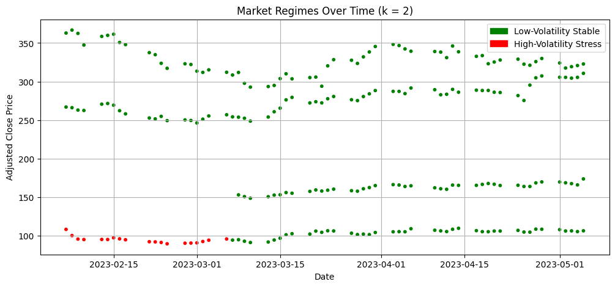

```python
import matplotlib.patches as mpatches

# Ensure Date is the index
df = df.set_index("Date")

# Define regime colors (by regime label)
regime_colors = {
    0: "green",  # Low-Volatility Stable
    1: "red"     # High-Volatility Stress
}

# Map colors to each data point
colors = df["regime"].map(regime_colors)

plt.figure(figsize=(12, 5))
plt.scatter(df.index, df["Adj Close"], c=colors, s=10)

plt.title("Market Regimes Over Time (k = 2)")
plt.xlabel("Date")
plt.ylabel("Adjusted Close Price")
plt.grid(True)

# Create legend manually
legend_handles = [
    mpatches.Patch(color="green", label="Low-Volatility Stable"),
    mpatches.Patch(color="red", label="High-Volatility Stress"),
]

plt.legend(handles=legend_handles)
plt.show()
```

```python
kmeans = KMeans(n_clusters=3, random_state=42)
df["regime"] = kmeans.fit_predict(X_scaled)
df.groupby("regime")[features].mean()
```

| regime | log_return | vol_20 | mom_20 | range | vol_ratio |
| --- | --- | --- | --- | --- | --- |
| 0 | 0.001754 | 0.020098 | 0.022824 | 0.023968 | 0.952163 |
| 1 | -0.073633 | 0.243898 | -0.546656 | 0.027373 | 2.051841 |
| 2 | 0.021984 | 0.107789 | 0.174209 | 0.021226 | 0.609446 |

Regime 0 represents a low-volatility, stable market environment characterized by modest positive returns, mild upward momentum, and near-average trading volume. Regime 1 corresponds to a high-volatility stress regime marked by strongly negative returns, pronounced downward momentum, elevated intraday price swings, and significantly increased trading volume. Regime 2 reflects a bullish growth regime with the highest average returns, strong positive momentum, moderate volatility, and relatively subdued trading activity.

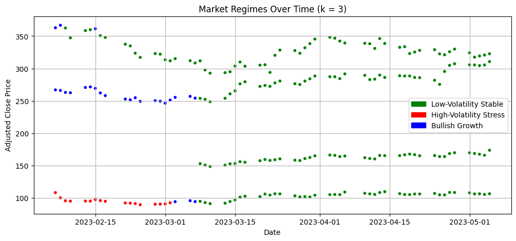

```python
import matplotlib.patches as mpatches

# Define regime colors (by regime label)
regime_colors = {
    0: "green",  # Low-Volatility Stable
    1: "red",    # High-Volatility Stress
    2: "blue"    # Bullish Growth
}

# Map colors to each data point
colors = df["regime"].map(regime_colors)

plt.figure(figsize=(12, 5))
plt.scatter(df.index, df["Adj Close"], c=colors, s=10)

plt.title("Market Regimes Over Time (k = 3)")
plt.xlabel("Date")
plt.ylabel("Adjusted Close Price")
plt.grid(True)

# Create legend manually
legend_handles = [
    mpatches.Patch(color="green", label="Low-Volatility Stable"),
    mpatches.Patch(color="red", label="High-Volatility Stress"),
    mpatches.Patch(color="blue", label="Bullish Growth"),
]

plt.legend(handles=legend_handles)
plt.show()
```

```python
kmeans = KMeans(n_clusters=6, random_state=42)
df["regime"] = kmeans.fit_predict(X_scaled)
df.groupby("regime")[features].mean()
```

| regime | log_return | vol_20 | mom_20 | range | vol_ratio |
| --- | --- | --- | --- | --- | --- |
| 0 | 0.001100 | 0.019573 | 0.023421 | 0.018645 | 0.822385 |
| 1 | -0.008176 | 0.243871 | -0.519457 | 0.025492 | 1.861738 |
| 2 | 0.019473 | 0.095648 | 0.191154 | 0.022724 | 0.555920 |
| 3 | -1.094408 | 0.244776 | -0.659071 | 0.047408 | 4.087567 |
| 4 | 0.007204 | 0.019363 | 0.032452 | 0.024996 | 1.946452 |
| 5 | 0.002769 | 0.022522 | 0.007392 | 0.040593 | 1.076147 |

Regime 0 represents a very low-volatility, low-activity market state with small positive returns, mild momentum, narrow intraday ranges, and below-average trading volume, consistent with quiet and stable trading periods. Regime 1 corresponds to a high-volatility downturn characterized by negative returns, strong negative momentum, elevated intraday price swings, and significantly increased trading volume, indicative of stress-driven selloffs. Regime 2 reflects a moderately volatile bullish state with strong positive returns and momentum, suggesting short-lived growth phases occurring alongside increased but controlled volatility. Regime 3 captures extreme stress conditions marked by exceptionally large negative returns, very high volatility, sharp downward momentum, wide intraday ranges, and unusually high trading volume, consistent with crisis-like market events. Regimes 4 and 5 represent transitional states, with Regime 4 showing modest positive returns under low volatility but elevated volume, and Regime 5 exhibiting relatively neutral returns paired with increased intraday variability, highlighting periods of uncertainty and regime transition rather than distinct market phases.

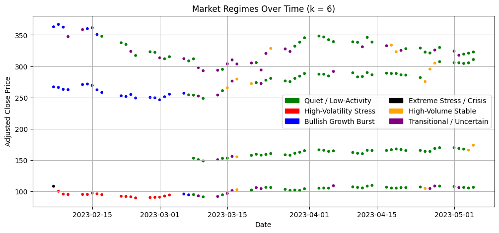

```python
import matplotlib.patches as mpatches

# Define regime colors (distinct but consistent)
regime_colors = {
    0: "green",     # Quiet / Low-Activity State
    1: "red",       # High-Volatility Stress
    2: "blue",      # Bullish Growth Burst
    3: "black",     # Extreme Stress / Crisis
    4: "orange",    # High-Volume Stable
    5: "purple"     # Transitional / Uncertain
}

# Map colors to each data point
colors = df["regime"].map(regime_colors)

plt.figure(figsize=(12, 5))
plt.scatter(df.index, df["Adj Close"], c=colors, s=10)

plt.title("Market Regimes Over Time (k = 6)")
plt.xlabel("Date")
plt.ylabel("Adjusted Close Price")
plt.grid(True)

# Create legend manually
legend_handles = [
    mpatches.Patch(color="green", label="Quiet / Low-Activity"),
    mpatches.Patch(color="red", label="High-Volatility Stress"),
    mpatches.Patch(color="blue", label="Bullish Growth Burst"),
    mpatches.Patch(color="black", label="Extreme Stress / Crisis"),
    mpatches.Patch(color="orange", label="High-Volume Stable"),
    mpatches.Patch(color="purple", label="Transitional / Uncertain"),
]

plt.legend(handles=legend_handles, ncol=2)
plt.show()
```

## **8. Interpretation of Market Regime Results**

In the k = 2 visualization, the clustering produces a clear binary separation between extended low-volatility periods and shorter, concentrated high-volatility stress episodes, which appear as brief but intense deviations in price behavior. This representation emphasizes the dominant macro structure of the market, where most observations fall into stable conditions punctuated by sharp stress events.

In the k = 6 visualization, the regime assignments become more fragmented, revealing finer-grained latent states that frequently alternate over time. While this higher resolution captures transitional behavior, extreme stress events, and subtle shifts in activity, it also results in increased visual complexity and reduced regime persistence, reflecting probabilistic micro-states rather than clearly separable economic regimes.

## **9. Exploring Market Regimes at k = 3**

While multiple clustering resolutions were explored, k = 3 was selected for deeper evaluation as it provides a balanced representation of market regimes that captures both dominant structural differences and economically interpretable behavior.

This histogram shows how long each market regime persists before switching to another regime. The x-axis represents the number of consecutive days spent in a regime, while the y-axis shows how many separate times (episodes) the market remained in that regime for that duration, rather than the total number of days.

[figure not shown]

```python
# Identify regime changes
df["regime_change"] = df["regime"] != df["regime"].shift(1)
df["regime_group"] = df["regime_change"].cumsum()

# Compute consecutive duration lengths
durations = (
    df.groupby(["regime_group", "regime"])
      .size()
      .reset_index(name="duration")
)

plt.figure(figsize=(10, 6))

# Plot histogram for each regime
for regime, color, label in [
    (0, "green", "Low-Volatility Stable"),
    (1, "red", "High-Volatility Stress"),
    (2, "blue", "Bullish Growth"),
]:
    subset = durations[durations["regime"] == regime]["duration"]
    plt.hist(
        subset,
        bins=20,
        alpha=0.6,
        color=color,
        label=label
    )

plt.xlabel("Consecutive Days in Regime")
plt.ylabel("Frequency")
plt.title("Distribution of Regime Durations (k = 3)")
plt.legend()
plt.grid(True)
plt.show()
```

This transition heatmap shows the probability of moving from one market regime to another on the following day. Each row represents the current regime, each column represents the next-day regime, and darker cells indicate more frequent transitions.

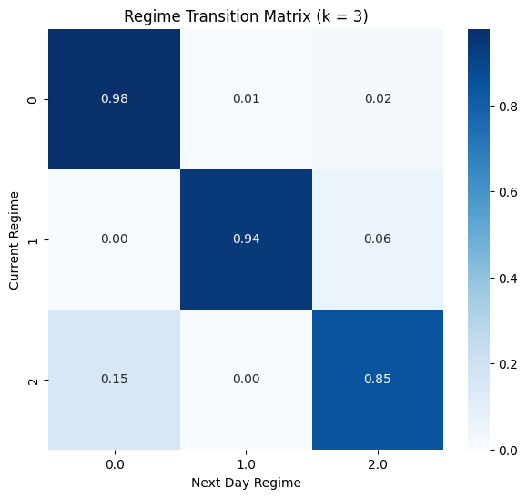

```python
import seaborn as sns

# Refit k = 3 model
kmeans = KMeans(n_clusters=3, random_state=42)
df["regime"] = kmeans.fit_predict(X_scaled)

# Create next-day regime column
df["next_regime"] = df["regime"].shift(-1)

# Drop last row (no next day)
transitions = df.dropna(subset=["next_regime"])

# Compute transition counts
transition_counts = pd.crosstab(
    transitions["regime"],
    transitions["next_regime"],
    normalize="index"  # convert to probabilities
)

transition_counts

plt.figure(figsize=(7, 6))

sns.heatmap(
    transition_counts,
    annot=True,
    fmt=".2f",
    cmap="Blues",
    cbar=True
)

plt.title("Regime Transition Matrix (k = 3)")
plt.xlabel("Next Day Regime")
plt.ylabel("Current Regime")
plt.show()
```

The transition matrix reveals strong persistence across all three market regimes, as indicated by high probabilities along the diagonal. The low-volatility stable regime is the most persistent, while the high-volatility stress regime tends to resolve into a bullish recovery rather than immediately returning to stability. Bullish growth regimes exhibit moderate persistence and frequently transition back into stable conditions, suggesting mean-reverting behavior. Overall, the transition patterns demonstrate that the identified regimes represent meaningful temporal states with intuitive market dynamics rather than random day-to-day fluctuations.

To illustrate how individual assets behave within the identified market regimes, cumulative returns are evaluated for Apple (AAPL) as a representative large-cap equity. This analysis highlights how AAPL’s performance is influenced by different market states while keeping regime definitions fixed at the market level.

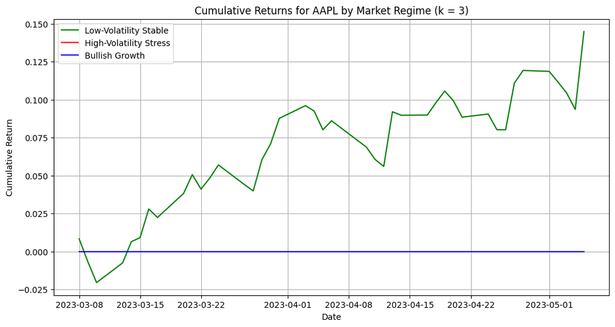

```python
# Select AAPL only
df_aapl = df[df["Ticker"] == "AAPL"].copy()

# Ensure proper ordering
df_aapl = df_aapl.sort_index()

plt.figure(figsize=(12, 6))

colors = {
    0: "green",  # Low-Volatility Stable
    1: "red",    # High-Volatility Stress
    2: "blue"    # Bullish Growth
}

labels = {
    0: "Low-Volatility Stable",
    1: "High-Volatility Stress",
    2: "Bullish Growth"
}

for regime in [0, 1, 2]:
    masked_returns = df_aapl["log_return"].where(
        df_aapl["regime"] == regime, 0.0
    )
    cumulative_return = np.exp(masked_returns.cumsum()) - 1

    plt.plot(
        df_aapl.index,
        cumulative_return,
        color=colors[regime],
        label=labels[regime]
    )

plt.title("Cumulative Returns for AAPL by Market Regime (k = 3)")
plt.xlabel("Date")
plt.ylabel("Cumulative Return")
plt.grid(True)
plt.legend()
plt.show()
```

The cumulative return profile for Apple (AAPL) is driven almost entirely by the low-volatility stable regime, which exhibits a gradual and consistent upward trend over time. The bullish growth regime contributes negligibly to cumulative returns, appearing as a flat line, while the high-volatility stress regime is effectively absent, indicating that AAPL rarely experiences extreme market conditions.

To illustrate how individual assets behave within the identified market regimes, cumulative returns are evaluated for Netflix (NFLX) as a representative large-cap equity. This analysis highlights how NFLX’s performance is influenced by different market states while keeping regime definitions fixed at the market level.

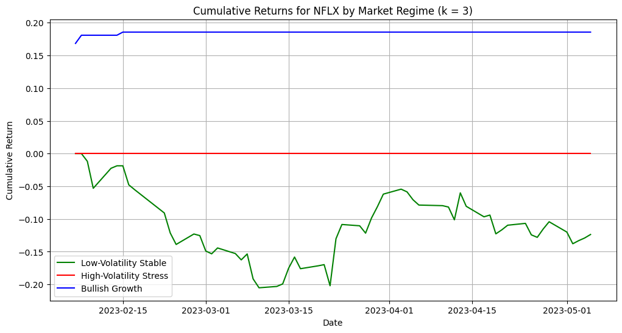

```python
# Select NFLX only
df_nflx = df[df["Ticker"] == "NFLX"].copy()

# Ensure proper ordering
df_nflx = df_nflx.sort_index()

plt.figure(figsize=(12, 6))

colors = {
    0: "green",  # Low-Volatility Stable
    1: "red",    # High-Volatility Stress
    2: "blue"    # Bullish Growth
}

labels = {
    0: "Low-Volatility Stable",
    1: "High-Volatility Stress",
    2: "Bullish Growth"
}

for regime in [0, 1, 2]:
    masked_returns = df_nflx["log_return"].where(
        df_nflx["regime"] == regime, 0.0
    )
    cumulative_return = np.exp(masked_returns.cumsum()) - 1

    plt.plot(
        df_nflx.index,
        cumulative_return,
        color=colors[regime],
        label=labels[regime]
    )

plt.title("Cumulative Returns for NFLX by Market Regime (k = 3)")
plt.xlabel("Date")
plt.ylabel("Cumulative Return")
plt.grid(True)
plt.legend()
plt.show()
```

The cumulative return profile for Netflix (NFLX) reveals a strong dependence on the bullish growth regime, where the majority of positive returns are generated. In contrast, NFLX experiences sustained losses during the low-volatility stable regime, indicating underperformance in calm market conditions. The high-volatility stress regime contributes negligibly to NFLX’s performance, suggesting that its price dynamics are driven more by growth-oriented market phases than by crisis periods. Compared to AAPL, this behavior highlights NFLX’s greater sensitivity to regime changes and reinforces the asset-dependent impact of the identified market states.

## **10. Conclusion and Future Studies**

A natural extension of this work would be to incorporate supervised learning methods to predict future market regimes using historical feature data. Regime labels derived from the unsupervised clustering could serve as targets for classification models, allowing evaluation of whether regime transitions are predictable in advance. Additionally, regime information could be integrated into return or volatility prediction models to assess whether regime awareness improves predictive performance.